# Stepwise Regression in Forecasting Tasks

Kadir İnip

14 02 2021

### Introduction

In this project, the focused subject is building a linear regression model with two different way, manually building and following given steps and using step() function. The manual builded model and step function gives us the same linear regression model which can be understand that the taken steps are valid and exact. In the report, I will firstly introduce by creating correlation and scatter plot, then by using stepwise regression steps building a regression model, then by using step() function building the same model. At the end of the report, preparing a hypothesis testing for GPA variable and test it. Finally, making our comments and completed the report.

Libraries and required importing and manipulations:

### Correlogram and Scatter Plot by Colored Correlation Values

First of all, the corelogram includes correlation values between each variable in the dataset. In the corelogram plot, the descending ordered correlation values between Sales volume are AGE, APT, GPA, EXP, ANX respectively.

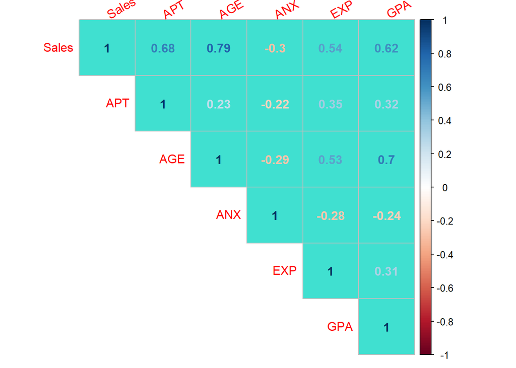

```r
correlation <- cor(data)
corrplot(correlation, method = "number", type = "upper", bg= "turquoise", tl.srt = 30)
```

The scatter plot will be:

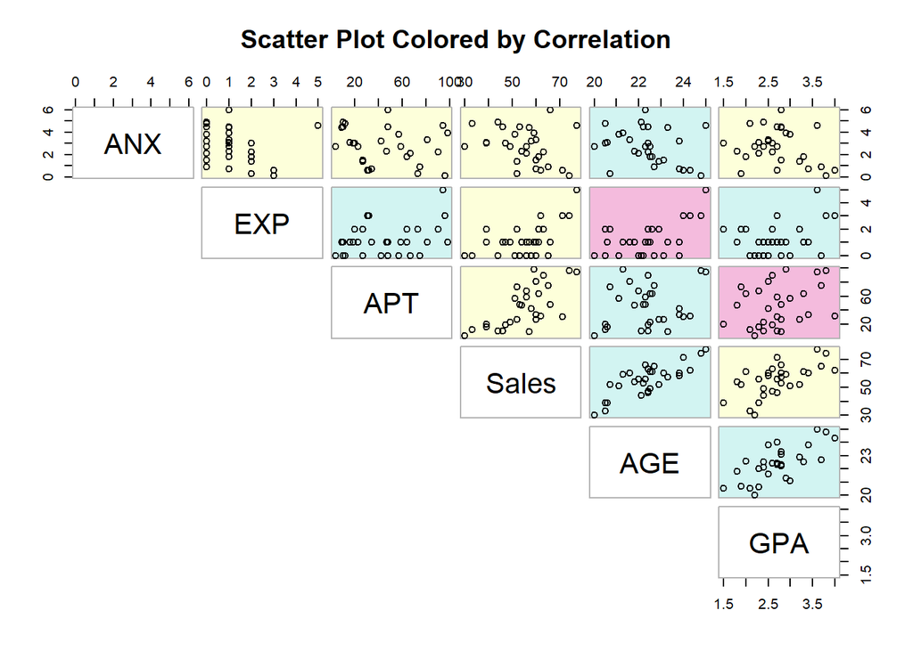

```r
data.r <- abs(cor(data))
data.col <- dmat.color(data.r)
data.o <- order.single(data.r)
cpairs(data, data.o, panel.colors=data.col, gap=.5, lower.panel = NULL, main="Scatter Plot Colored by Correlation")
```

In the scatter plot, it can be understand easily that AGE and Sales values are correlated as the points on the plot are close to y=x line. The variables between highest R^2 correlation values shows an increasing trend. I think that, the AGE, APT and GPA variables can have impacts on Sales.

### Stepwise Regression

The highest correlation value between variables can be found:

```r
sort(data.r, decreasing=T)[7]
```

```
## [1] 0.7915973
```

Data.r keeps the absolute of the correlation between variables and the first 6 index include the correlation for every variable between itself. So, the highest correlation is 0.7915 which is between Sales and AGE. So, keeping AGE for first regressors.

```r
currentmodel <- lm(formula = Sales ~ AGE, data= data)
summary(currentmodel)
```

```
##
## Call:
## lm(formula = Sales ~ AGE, data = data)
##
## Residuals:
##     Min      1Q  Median      3Q     Max
## -9.2810 -6.6102  0.6617  4.7184 11.4048
##
## Coefficients:
##             Estimate Std. Error t value Pr(>|t|)
## (Intercept)  -98.335     22.428  -4.385 0.000149 ***
## AGE            6.858      1.000   6.855  1.9e-07 ***
## ---
## Signif. codes:  0 '***' 0.001 '**' 0.01 '*' 0.05 '.' 0.1 ' ' 1
##
## Residual standard error: 6.904 on 28 degrees of freedom
## Multiple R-squared:  0.6266, Adjusted R-squared:  0.6133
## F-statistic: 46.99 on 1 and 28 DF,  p-value: 1.896e-07
```

For building the initial model, we will add new variables which are on the correlation table, this is the second step. Then at the end of the step we will use F-test statistics and select the best model with respect to p-value, to do that we will use anova() function.

```r
newmodel <- lm(formula = Sales ~ AGE + APT, data = data)    # the best F-value is AGE + APT
anova(currentmodel, newmodel)
```

```
## Analysis of Variance Table
##
## Model 1: Sales ~ AGE
## Model 2: Sales ~ AGE + APT
##   Res.Df     RSS Df Sum of Sq      F Pr(>F)
## 1     28 1334.50
## 2     27  387.47  1    947.03 65.992  1e-08 ***
## ---
## Signif. codes:  0 '***' 0.001 '**' 0.01 '*' 0.05 '.' 0.1 ' ' 1
```

```r
newmodel <- lm(formula = Sales ~ AGE + ANX, data = data)
anova(currentmodel, newmodel)
```

```
## Analysis of Variance Table
##
## Model 1: Sales ~ AGE
## Model 2: Sales ~ AGE + ANX
##   Res.Df    RSS Df Sum of Sq      F Pr(>F)
## 1     28 1334.5
## 2     27 1312.5  1     21.98 0.4522  0.507
```

```r
newmodel <- lm(formula = Sales ~ AGE + EXP, data = data)
anova(currentmodel, newmodel)
```

```
## Analysis of Variance Table
##
## Model 1: Sales ~ AGE
## Model 2: Sales ~ AGE + EXP
##   Res.Df    RSS Df Sum of Sq      F Pr(>F)
## 1     28 1334.5
## 2     27 1259.4  1    75.128 1.6107 0.2152
```

```r
newmodel <- lm(formula = Sales ~ AGE + GPA, data = data)
anova(currentmodel, newmodel)
```

```
## Analysis of Variance Table
##
## Model 1: Sales ~ AGE
## Model 2: Sales ~ AGE + GPA
##   Res.Df    RSS Df Sum of Sq      F Pr(>F)
## 1     28 1334.5
## 2     27 1307.9  1    26.638 0.5499 0.4648
```

After trying different models, it is observed that the next variable for building an appropriate model is APT which is significant and the has the lowest p-value. We can update our model by adding APT variable.

Then in the step 3, we will remove the initial first variable (AGE) and try to find whether model improved or not:

```r
currentmodel <- lm(formula = Sales ~ AGE + APT, data = data)
newmodel <- lm(formula  = Sales ~ APT, data = data)
anova(currentmodel, newmodel)
```

```
## Analysis of Variance Table
##
## Model 1: Sales ~ AGE + APT
## Model 2: Sales ~ APT
##   Res.Df     RSS Df Sum of Sq      F    Pr(>F)
## 1     27  387.47
## 2     28 1902.00 -1   -1514.5 105.54 7.939e-11 ***
## ---
## Signif. codes:  0 '***' 0.001 '**' 0.01 '*' 0.05 '.' 0.1 ' ' 1
```

The p-value is really close to zero (7.939*e-11) which means that AGE is significant for our model, so it shouldn’t remove our linear regression model.

Then we’ll move on step2&3 until there are no improvement yet. The next step is whether new variable is significant or not, is it added or not?

```r
newmodel <- lm(formula = Sales~ AGE + APT + ANX, data = data)
anova(currentmodel, newmodel)
```

```
## Analysis of Variance Table
##
## Model 1: Sales ~ AGE + APT
## Model 2: Sales ~ AGE + APT + ANX
##   Res.Df    RSS Df Sum of Sq     F Pr(>F)
## 1     27 387.47
## 2     26 387.27  1   0.19312 0.013 0.9102
```

```r
newmodel <- lm(formula = Sales~ AGE + APT + EXP, data = data)
anova(currentmodel, newmodel)
```

```
## Analysis of Variance Table
##
## Model 1: Sales ~ AGE + APT
## Model 2: Sales ~ AGE + APT + EXP
##   Res.Df    RSS Df Sum of Sq      F Pr(>F)
## 1     27 387.47
## 2     26 387.42  1  0.047057 0.0032 0.9556
```

```r
newmodel <- lm(formula = Sales~ AGE + APT + GPA, data = data)
anova(currentmodel, newmodel)
```

```
## Analysis of Variance Table
##
## Model 1: Sales ~ AGE + APT
## Model 2: Sales ~ AGE + APT + GPA
##   Res.Df    RSS Df Sum of Sq      F Pr(>F)
## 1     27 387.47
## 2     26 384.56  1    2.9087 0.1967 0.6611
```

The lowest GPA is found when GPA added however, its significance level is not enough for adding our linear model. So, the current model was founded with the help of AGE and APT variables.

```
##
## Call:
## lm(formula = Sales ~ AGE + APT, data = data)
##
## Residuals:
##    Min     1Q Median     3Q    Max
## -5.271 -2.275 -1.065  1.415 10.893
##
## Coefficients:
##             Estimate Std. Error t value Pr(>|t|)
## (Intercept) -83.8357    12.4356  -6.742 3.08e-07 ***
## AGE           5.7969     0.5643  10.273 7.94e-11 ***
## APT           0.2015     0.0248   8.124 1.00e-08 ***
## ---
## Signif. codes:  0 '***' 0.001 '**' 0.01 '*' 0.05 '.' 0.1 ' ' 1
##
## Residual standard error: 3.788 on 27 degrees of freedom
## Multiple R-squared:  0.8916, Adjusted R-squared:  0.8836
## F-statistic:   111 on 2 and 27 DF,  p-value: 9.404e-14
```

### Step() Function

In this section, we will build an appropriate model by using step() function and step function make some iterations and minimize the total AIC. Direction is important for creating step() function, as if there are more crowded variables in the dataset, “both” types of direction takes long time on the other hand, there are exactly 30 row and 6 columns, so using “both” direction and giving the route to the algorithm is the best way.

```r
step(lm(formula = Sales ~ 1, data = data), scope =~ APT + AGE + ANX + EXP + GPA, direction = "both", trace = 1)
```

```
## Start:  AIC=145.41
## Sales ~ 1
##
##        Df Sum of Sq    RSS    AIC
## + AGE   1   2239.67 1334.5 117.85
## + APT   1   1672.16 1902.0 128.48
## + GPA   1   1363.87 2210.3 132.99
## + EXP   1   1060.39 2513.8 136.85
## + ANX   1    330.86 3243.3 144.50
## <none>              3574.2 145.41
##
## Step:  AIC=117.85
## Sales ~ AGE
##
##        Df Sum of Sq    RSS     AIC
## + APT   1    947.03  387.5  82.753
## <none>              1334.5 117.853
## + EXP   1     75.13 1259.4 118.115
## + GPA   1     26.64 1307.9 119.249
## + ANX   1     21.98 1312.5 119.355
## - AGE   1   2239.67 3574.2 145.409
##
## Step:  AIC=82.75
## Sales ~ AGE + APT
##
##        Df Sum of Sq     RSS     AIC
## <none>               387.47  82.753
## + GPA   1      2.91  384.56  84.527
## + ANX   1      0.19  387.27  84.738
## + EXP   1      0.05  387.42  84.749
## - APT   1    947.03 1334.50 117.853
## - AGE   1   1514.54 1902.00 128.484
```

```
##
## Call:
## lm(formula = Sales ~ AGE + APT, data = data)
##
## Coefficients:
## (Intercept)          AGE          APT
##    -83.8357       5.7969       0.2015
```

The final regression model is not different our stepwise regression case which means that the first method is true enough to find appropriate model as expected. In the step() function, the algorithm works to minimize the total AIC values. It can say the model which Sales~AGE+APT is our final model.

#### Comparison Between Step() function and Stepwise Regression

It can be say that, both methods build the same model which is Sales ~ AGE + APT. And their coefficients are not different because step() function works minimizing the AIC error values and build lm model for each iteration, if the next iteration hasn’t a lowest AIC value, the step() function stops and gives the final model. Like in the stepwise regression steps that we taken via using p-values and significance values.

### Final Model

The final model is Sales ~ AGE + APT, and the summary of the model is:

```
##
## Call:
## lm(formula = Sales ~ AGE + APT, data = data)
##
## Residuals:
##    Min     1Q Median     3Q    Max
## -5.271 -2.275 -1.065  1.415 10.893
##
## Coefficients:
##             Estimate Std. Error t value Pr(>|t|)
## (Intercept) -83.8357    12.4356  -6.742 3.08e-07 ***
## AGE           5.7969     0.5643  10.273 7.94e-11 ***
## APT           0.2015     0.0248   8.124 1.00e-08 ***
## ---
## Signif. codes:  0 '***' 0.001 '**' 0.01 '*' 0.05 '.' 0.1 ' ' 1
##
## Residual standard error: 3.788 on 27 degrees of freedom
## Multiple R-squared:  0.8916, Adjusted R-squared:  0.8836
## F-statistic:   111 on 2 and 27 DF,  p-value: 9.404e-14
```

-The estimate of the Yo is -83.8357 and its significant level is under 0.0001

-The estimate of the coefficient of AGE value is 5.7969 and its significance level is under 0.0001

-The estimate of the coefficient of APT value is 0.2015 and its significance level is under 0.0001

-The residual standard error of the model is 3.788 on 27 degrees of freedom as n=30 and k=2, the degrees of freedom is n-k-1 so 27. F-statistic will be 111 for 2 and 27 degrees of freedom.

### GPA Effect on the Model

The question says that * HO = High school GPA’s coefficient on the model is equal to zero * H1 = High school GPA coefficient on the model isn’t equal zero. * significance level alpha = 0.1

```r
newmodel <- lm(formula = Sales ~AGE + APT + GPA, data = data)
summary(newmodel)
```

```
##
## Call:
## lm(formula = Sales ~ AGE + APT + GPA, data = data)
##
## Residuals:
##     Min      1Q  Median      3Q     Max
## -5.1466 -2.2892 -0.8423  1.5086 10.9757
##
## Coefficients:
##              Estimate Std. Error t value Pr(>|t|)
## (Intercept) -87.20756   14.73768  -5.917 3.05e-06 ***
## AGE           6.03388    0.78345   7.702 3.58e-08 ***
## APT           0.20404    0.02582   7.901 2.23e-08 ***
## GPA          -0.75632    1.70548  -0.443    0.661
## ---
## Signif. codes:  0 '***' 0.001 '**' 0.01 '*' 0.05 '.' 0.1 ' ' 1
##
## Residual standard error: 3.846 on 26 degrees of freedom
## Multiple R-squared:  0.8924, Adjusted R-squared:   0.88
## F-statistic: 71.88 on 3 and 26 DF,  p-value: 1.028e-12
```

- The t-value of the new added variable is -0.443 which is very close to 0 and p-value of the new added variable GPA is 0.661
- 0.661 > 0.10 significance level, so we can fail to reject Ho.

### Conclusion

RMD file is [here](https://bu-ie-360.github.io/fall20-kadirnp/files/HMW5.Rmd).